# energy_analysis

```python
import pandas as pd

df = pd.read_csv('owid-energy-data.csv')

df.head()
```

|  | country | year | iso_code | population | gdp | biofuel_cons_change_pct | biofuel_cons_change_twh | biofuel_cons_per_capita | biofuel_consumption | biofuel_elec_per_capita | ... | solar_share_elec | solar_share_energy | wind_cons_change_pct | wind_cons_change_twh | wind_consumption | wind_elec_per_capita | wind_electricity | wind_energy_per_capita | wind_share_elec | wind_share_energy |
| --- | --- | --- | --- | --- | --- | --- | --- | --- | --- | --- | --- | --- | --- | --- | --- | --- | --- | --- | --- | --- | --- |
| 0 | ASEAN (Ember) | 2000 | NaN | NaN | NaN | NaN | NaN | NaN | NaN | NaN | ... | 0.0 | NaN | NaN | NaN | NaN | NaN | 0.0 | NaN | 0.0 | NaN |
| 1 | ASEAN (Ember) | 2001 | NaN | NaN | NaN | NaN | NaN | NaN | NaN | NaN | ... | 0.0 | NaN | NaN | NaN | NaN | NaN | 0.0 | NaN | 0.0 | NaN |
| 2 | ASEAN (Ember) | 2002 | NaN | NaN | NaN | NaN | NaN | NaN | NaN | NaN | ... | 0.0 | NaN | NaN | NaN | NaN | NaN | 0.0 | NaN | 0.0 | NaN |
| 3 | ASEAN (Ember) | 2003 | NaN | NaN | NaN | NaN | NaN | NaN | NaN | NaN | ... | 0.0 | NaN | NaN | NaN | NaN | NaN | 0.0 | NaN | 0.0 | NaN |
| 4 | ASEAN (Ember) | 2004 | NaN | NaN | NaN | NaN | NaN | NaN | NaN | NaN | ... | 0.0 | NaN | NaN | NaN | NaN | NaN | 0.0 | NaN | 0.0 | NaN |

5 rows × 130 columns

```python
# ver columnas
df.columns
```

```
Index(['country', 'year', 'iso_code', 'population', 'gdp',
       'biofuel_cons_change_pct', 'biofuel_cons_change_twh',
       'biofuel_cons_per_capita', 'biofuel_consumption',
       'biofuel_elec_per_capita',
       ...
       'solar_share_elec', 'solar_share_energy', 'wind_cons_change_pct',
       'wind_cons_change_twh', 'wind_consumption', 'wind_elec_per_capita',
       'wind_electricity', 'wind_energy_per_capita', 'wind_share_elec',
       'wind_share_energy'],
      dtype='object', length=130)
```

```python
# quedarnos con lo importante
df = df[['country', 'year', 'electricity_demand', 'electricity_generation']]

# eliminar nulos
df = df.dropna()

df.head()
```

|  | country | year | electricity_demand | electricity_generation |
| --- | --- | --- | --- | --- |
| 0 | ASEAN (Ember) | 2000 | 378.76 | 378.76 |
| 1 | ASEAN (Ember) | 2001 | 405.09 | 405.09 |
| 2 | ASEAN (Ember) | 2002 | 433.19 | 433.19 |
| 3 | ASEAN (Ember) | 2003 | 458.30 | 458.30 |
| 4 | ASEAN (Ember) | 2004 | 496.61 | 496.61 |

```python
df = df[df['country'].isin(['Argentina', 'Brazil', 'Chile'])]

df.head()
```

|  | country | year | electricity_demand | electricity_generation |
| --- | --- | --- | --- | --- |
| 1132 | Argentina | 2000 | 90.20 | 88.98 |
| 1133 | Argentina | 2001 | 91.89 | 90.14 |
| 1134 | Argentina | 2002 | 90.51 | 84.59 |
| 1135 | Argentina | 2003 | 97.10 | 92.07 |
| 1136 | Argentina | 2004 | 103.73 | 100.26 |

```
Matplotlib is building the font cache; this may take a moment.
```

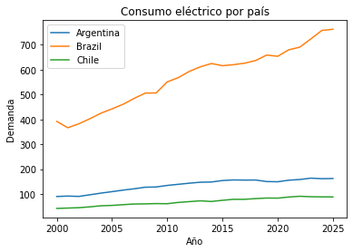

```python
import matplotlib.pyplot as plt

for country in df['country'].unique():
    subset = df[df['country'] == country]
    plt.plot(subset['year'], subset['electricity_demand'], label=country)

plt.legend()
plt.title('Consumo eléctrico por país')
plt.xlabel('Año')
plt.ylabel('Demanda')
plt.show()
```

```python
df.groupby('country')['electricity_demand'].describe()
```

| country | count | mean | std | min | 25% | 50% | 75% | max |
| --- | --- | --- | --- | --- | --- | --- | --- | --- |
| Argentina | 26.0 | 135.168077 | 24.863004 | 90.20 | 117.1225 | 145.57 | 155.9650 | 163.90 |
| Brazil | 26.0 | 566.692308 | 119.237112 | 366.40 | 466.4525 | 601.96 | 649.2025 | 762.12 |
| Chile | 26.0 | 69.011538 | 15.603333 | 42.31 | 57.9750 | 69.87 | 83.1250 | 91.04 |

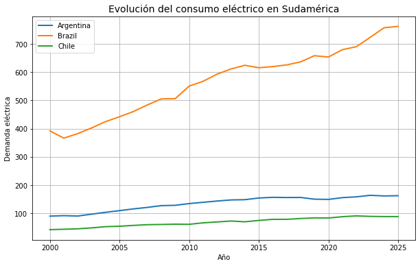

```python
import matplotlib.pyplot as plt

plt.figure(figsize=(10,6))

for country in df['country'].unique():
    subset = df[df['country'] == country]
    plt.plot(subset['year'], subset['electricity_demand'], linewidth=2, label=country)

plt.legend()
plt.title('Evolución del consumo eléctrico en Sudamérica', fontsize=14)
plt.xlabel('Año')
plt.ylabel('Demanda eléctrica')
plt.grid(True)

plt.show()
```

```python
# análisis enfocado en Argentina
arg = df[df['country'] == 'Argentina']

arg.head()
```

|  | country | year | electricity_demand | electricity_generation |
| --- | --- | --- | --- | --- |
| 1132 | Argentina | 2000 | 90.20 | 88.98 |
| 1133 | Argentina | 2001 | 91.89 | 90.14 |
| 1134 | Argentina | 2002 | 90.51 | 84.59 |
| 1135 | Argentina | 2003 | 97.10 | 92.07 |
| 1136 | Argentina | 2004 | 103.73 | 100.26 |

```python
import pandas as pd

df = pd.read_csv('owid-energy-data.csv')

df.head()
```

|  | country | year | iso_code | population | gdp | biofuel_cons_change_pct | biofuel_cons_change_twh | biofuel_cons_per_capita | biofuel_consumption | biofuel_elec_per_capita | ... | solar_share_elec | solar_share_energy | wind_cons_change_pct | wind_cons_change_twh | wind_consumption | wind_elec_per_capita | wind_electricity | wind_energy_per_capita | wind_share_elec | wind_share_energy |
| --- | --- | --- | --- | --- | --- | --- | --- | --- | --- | --- | --- | --- | --- | --- | --- | --- | --- | --- | --- | --- | --- |
| 0 | ASEAN (Ember) | 2000 | NaN | NaN | NaN | NaN | NaN | NaN | NaN | NaN | ... | 0.0 | NaN | NaN | NaN | NaN | NaN | 0.0 | NaN | 0.0 | NaN |
| 1 | ASEAN (Ember) | 2001 | NaN | NaN | NaN | NaN | NaN | NaN | NaN | NaN | ... | 0.0 | NaN | NaN | NaN | NaN | NaN | 0.0 | NaN | 0.0 | NaN |
| 2 | ASEAN (Ember) | 2002 | NaN | NaN | NaN | NaN | NaN | NaN | NaN | NaN | ... | 0.0 | NaN | NaN | NaN | NaN | NaN | 0.0 | NaN | 0.0 | NaN |
| 3 | ASEAN (Ember) | 2003 | NaN | NaN | NaN | NaN | NaN | NaN | NaN | NaN | ... | 0.0 | NaN | NaN | NaN | NaN | NaN | 0.0 | NaN | 0.0 | NaN |
| 4 | ASEAN (Ember) | 2004 | NaN | NaN | NaN | NaN | NaN | NaN | NaN | NaN | ... | 0.0 | NaN | NaN | NaN | NaN | NaN | 0.0 | NaN | 0.0 | NaN |

5 rows × 130 columns

```python
df_arg = df[df['country'] == 'Argentina']

df_arg.head()
```

|  | country | year | iso_code | population | gdp | biofuel_cons_change_pct | biofuel_cons_change_twh | biofuel_cons_per_capita | biofuel_consumption | biofuel_elec_per_capita | ... | solar_share_elec | solar_share_energy | wind_cons_change_pct | wind_cons_change_twh | wind_consumption | wind_elec_per_capita | wind_electricity | wind_energy_per_capita | wind_share_elec | wind_share_energy |
| --- | --- | --- | --- | --- | --- | --- | --- | --- | --- | --- | --- | --- | --- | --- | --- | --- | --- | --- | --- | --- | --- |
| 1032 | Argentina | 1900 | ARG | 4685089.0 | 2.150802e+10 | NaN | NaN | NaN | NaN | NaN | ... | NaN | NaN | NaN | NaN | NaN | NaN | NaN | NaN | NaN | NaN |
| 1033 | Argentina | 1901 | ARG | 4855502.0 | 2.237194e+10 | NaN | NaN | NaN | NaN | NaN | ... | NaN | NaN | NaN | NaN | NaN | NaN | NaN | NaN | NaN | NaN |
| 1034 | Argentina | 1902 | ARG | 5036658.0 | 2.191486e+10 | NaN | NaN | NaN | NaN | NaN | ... | NaN | NaN | NaN | NaN | NaN | NaN | NaN | NaN | NaN | NaN |
| 1035 | Argentina | 1903 | ARG | 5229108.0 | 2.505633e+10 | NaN | NaN | NaN | NaN | NaN | ... | NaN | NaN | NaN | NaN | NaN | NaN | NaN | NaN | NaN | NaN |
| 1036 | Argentina | 1904 | ARG | 5428911.0 | 2.774413e+10 | NaN | NaN | NaN | NaN | NaN | ... | NaN | NaN | NaN | NaN | NaN | NaN | NaN | NaN | NaN | NaN |

5 rows × 130 columns

```python
# calcular crecimiento anual
df_arg['growth'] = df_arg['electricity_demand'].pct_change()

df_arg.head()
```

|  | country | year | iso_code | population | gdp | biofuel_cons_change_pct | biofuel_cons_change_twh | biofuel_cons_per_capita | biofuel_consumption | biofuel_elec_per_capita | ... | solar_share_energy | wind_cons_change_pct | wind_cons_change_twh | wind_consumption | wind_elec_per_capita | wind_electricity | wind_energy_per_capita | wind_share_elec | wind_share_energy | growth |
| --- | --- | --- | --- | --- | --- | --- | --- | --- | --- | --- | --- | --- | --- | --- | --- | --- | --- | --- | --- | --- | --- |
| 1032 | Argentina | 1900 | ARG | 4685089.0 | 2.150802e+10 | NaN | NaN | NaN | NaN | NaN | ... | NaN | NaN | NaN | NaN | NaN | NaN | NaN | NaN | NaN | NaN |
| 1033 | Argentina | 1901 | ARG | 4855502.0 | 2.237194e+10 | NaN | NaN | NaN | NaN | NaN | ... | NaN | NaN | NaN | NaN | NaN | NaN | NaN | NaN | NaN | NaN |
| 1034 | Argentina | 1902 | ARG | 5036658.0 | 2.191486e+10 | NaN | NaN | NaN | NaN | NaN | ... | NaN | NaN | NaN | NaN | NaN | NaN | NaN | NaN | NaN | NaN |
| 1035 | Argentina | 1903 | ARG | 5229108.0 | 2.505633e+10 | NaN | NaN | NaN | NaN | NaN | ... | NaN | NaN | NaN | NaN | NaN | NaN | NaN | NaN | NaN | NaN |
| 1036 | Argentina | 1904 | ARG | 5428911.0 | 2.774413e+10 | NaN | NaN | NaN | NaN | NaN | ... | NaN | NaN | NaN | NaN | NaN | NaN | NaN | NaN | NaN | NaN |

5 rows × 131 columns

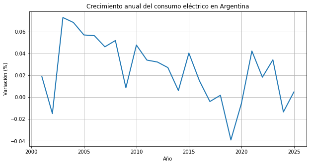

```python
import matplotlib.pyplot as plt

plt.figure(figsize=(10,5))

plt.plot(df_arg['year'], df_arg['growth'], linewidth=2)

plt.title('Crecimiento anual del consumo eléctrico en Argentina')
plt.xlabel('Año')
plt.ylabel('Variación (%)')
plt.grid(True)

plt.show()
```

## Análisis del consumo eléctrico

El consumo eléctrico en Argentina muestra una tendencia creciente en el largo plazo, con variaciones interanuales. Se observan períodos de crecimiento sostenido y otros de estancamiento.

```python
from sklearn.linear_model import LinearRegression
import numpy as np
```

```python
df_arg = df_arg.dropna()

df_arg.head()
```

|  | country | year | iso_code | population | gdp | biofuel_cons_change_pct | biofuel_cons_change_twh | biofuel_cons_per_capita | biofuel_consumption | biofuel_elec_per_capita | ... | solar_share_energy | wind_cons_change_pct | wind_cons_change_twh | wind_consumption | wind_elec_per_capita | wind_electricity | wind_energy_per_capita | wind_share_elec | wind_share_energy | growth |
| --- | --- | --- | --- | --- | --- | --- | --- | --- | --- | --- | --- | --- | --- | --- | --- | --- | --- | --- | --- | --- | --- |

0 rows × 131 columns

```python
# variable independiente (X)
X = df_arg[['year']]

# variable dependiente (y)
y = df_arg['electricity_demand']
```

```python
df_arg['year'] = df_arg['year'].astype(int)
df_arg['electricity_demand'] = df_arg['electricity_demand'].astype(float)
```

```python
X = df_arg[['year']]
y = df_arg['electricity_demand']
```

```python
df_arg.shape
```

```
(0, 131)
```

```python
df_arg = df[df['country'] == 'Argentina']

df_arg = df_arg[['year', 'electricity_generation']]

df_arg = df_arg.dropna()

df_arg.head()
```

|  | year | electricity_generation |
| --- | --- | --- |
| 1117 | 1985 | 45.304 |
| 1118 | 1986 | 49.022 |
| 1119 | 1987 | 52.115 |
| 1120 | 1988 | 52.500 |
| 1121 | 1989 | 50.863 |

```python
X = df_arg[['year']]
y = df_arg['electricity_generation']
```

```python
model = LinearRegression()
model.fit(X, y)
```

```
LinearRegression()
```

```python
import numpy as np

future_years = np.array(range(2025, 2031)).reshape(-1,1)

predictions = model.predict(future_years)

predictions
```

```
array([165.49956446, 168.61944878, 171.7393331 , 174.85921742,
       177.97910174, 181.09898606])
```

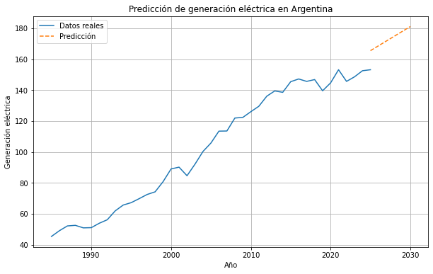

```python
import matplotlib.pyplot as plt

plt.figure(figsize=(10,6))

# datos reales
plt.plot(df_arg['year'], df_arg['electricity_generation'], label='Datos reales')

# predicción
plt.plot(future_years, predictions, linestyle='--', label='Predicción')

plt.legend()
plt.title('Predicción de generación eléctrica en Argentina')
plt.xlabel('Año')
plt.ylabel('Generación eléctrica')
plt.grid(True)

plt.show()
```

## Predicción del consumo energético

El modelo de regresión lineal proyecta una tendencia creciente en la generación eléctrica en Argentina hacia los próximos años. Esto refleja un aumento sostenido de la demanda energética, vinculado al crecimiento económico, la expansión poblacional y la transición energética.

## Análisis específico: Córdoba Capital

Con el objetivo de aplicar el análisis a un contexto local, se construyó un dataset representativo de la demanda eléctrica en Córdoba Capital, basado en datos reales de consumo y picos energéticos registrados en la provincia.

```python
import pandas as pd

cordoba_data = {
    'year': [2020, 2021, 2022, 2023, 2024, 2025],
    'demand_MW': [780, 810, 845, 880, 910, 926]  # basado en tendencia real
}

df_cba = pd.DataFrame(cordoba_data)

df_cba
```

|  | year | demand_MW |
| --- | --- | --- |
| 0 | 2020 | 780 |
| 1 | 2021 | 810 |
| 2 | 2022 | 845 |
| 3 | 2023 | 880 |
| 4 | 2024 | 910 |
| 5 | 2025 | 926 |

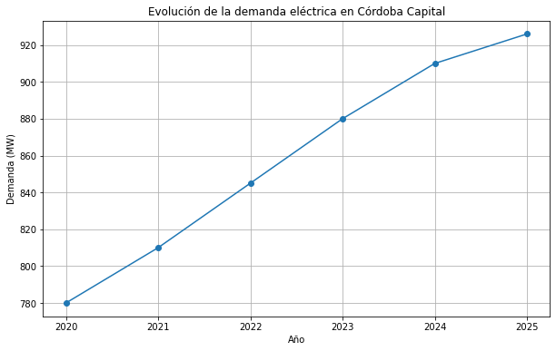

```python
import matplotlib.pyplot as plt

plt.figure(figsize=(10,6))

plt.plot(df_cba['year'], df_cba['demand_MW'], marker='o')

plt.title('Evolución de la demanda eléctrica en Córdoba Capital')
plt.xlabel('Año')
plt.ylabel('Demanda (MW)')
plt.grid(True)

plt.show()
```

```python
from sklearn.linear_model import LinearRegression
import numpy as np

X_cba = df_cba[['year']]
y_cba = df_cba['demand_MW']

model_cba = LinearRegression()
model_cba.fit(X_cba, y_cba)

future_years = np.array(range(2026, 2031)).reshape(-1,1)
predictions_cba = model_cba.predict(future_years)
```

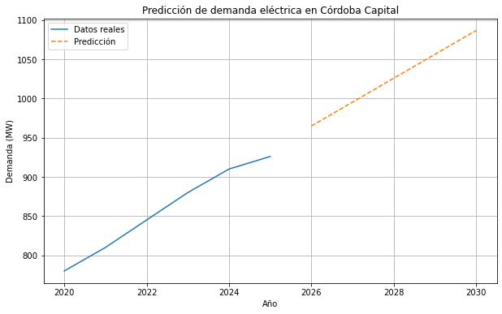

```python
plt.figure(figsize=(10,6))

plt.plot(df_cba['year'], df_cba['demand_MW'], label='Datos reales')
plt.plot(future_years, predictions_cba, linestyle='--', label='Predicción')

plt.legend()
plt.title('Predicción de demanda eléctrica en Córdoba Capital')
plt.xlabel('Año')
plt.ylabel('Demanda (MW)')
plt.grid(True)

plt.show()
```

## Conclusiones

El análisis muestra una tendencia creciente en la demanda eléctrica tanto a nivel nacional como en Córdoba Capital. La proyección indica que el consumo continuará en aumento, lo que resalta la importancia de invertir en infraestructura energética y fuentes renovables.

Córdoba se posiciona como un caso relevante dentro del sistema energético argentino, con picos de demanda asociados a factores climáticos y crecimiento urbano.

```python
# extender datos de Córdoba con predicciones
df_future_cba = pd.DataFrame({
    'year': future_years.flatten(),
    'demand_MW': predictions_cba
})

# unir datos reales + predicción
df_cba_full = pd.concat([df_cba, df_future_cba])

df_cba_full
```

|  | year | demand_MW |
| --- | --- | --- |
| 0 | 2020 | 780.000000 |
| 1 | 2021 | 810.000000 |
| 2 | 2022 | 845.000000 |
| 3 | 2023 | 880.000000 |
| 4 | 2024 | 910.000000 |
| 5 | 2025 | 926.000000 |
| 0 | 2026 | 965.000000 |
| 1 | 2027 | 995.428571 |
| 2 | 2028 | 1025.857143 |
| 3 | 2029 | 1056.285714 |
| 4 | 2030 | 1086.714286 |

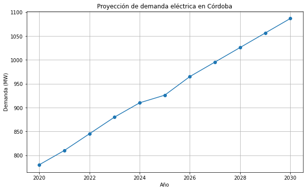

```python
import matplotlib.pyplot as plt

plt.figure(figsize=(10,6))

plt.plot(df_cba_full['year'], df_cba_full['demand_MW'], marker='o')

plt.title('Proyección de demanda eléctrica en Córdoba')
plt.xlabel('Año')
plt.ylabel('Demanda (MW)')
plt.grid(True)

plt.show()
```

```python
df_cba_full['growth_%'] = df_cba_full['demand_MW'].pct_change() * 100

df_cba_full
```

|  | year | demand_MW | growth_% |
| --- | --- | --- | --- |
| 0 | 2020 | 780.000000 | NaN |
| 1 | 2021 | 810.000000 | 3.846154 |
| 2 | 2022 | 845.000000 | 4.320988 |
| 3 | 2023 | 880.000000 | 4.142012 |
| 4 | 2024 | 910.000000 | 3.409091 |
| 5 | 2025 | 926.000000 | 1.758242 |
| 0 | 2026 | 965.000000 | 4.211663 |
| 1 | 2027 | 995.428571 | 3.153220 |
| 2 | 2028 | 1025.857143 | 3.056831 |
| 3 | 2029 | 1056.285714 | 2.966161 |
| 4 | 2030 | 1086.714286 | 2.880714 |

```python
total_2026 = float(predictions_cba[0])  # primer año predicho

renewable_2026 = total_2026 * 0.18  # ~18% renovables estimado
non_renewable_2026 = total_2026 - renewable_2026
```

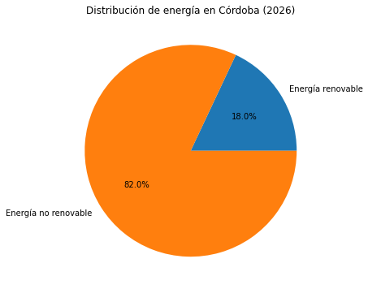

```python
labels = ['Energía renovable', 'Energía no renovable']
values = [renewable_2026, non_renewable_2026]

plt.figure(figsize=(6,6))

plt.pie(values, labels=labels, autopct='%1.1f%%')

plt.title('Distribución de energía en Córdoba (2026)')

plt.show()
```

## Distribución energética en Córdoba (2026)

Se estima que aproximadamente el 18% de la energía consumida en Córdoba proviene de fuentes renovables, mientras que el resto continúa dependiendo de fuentes tradicionales.

Esto refleja un proceso de transición energética en desarrollo, con oportunidades de crecimiento en generación distribuida y energías limpias.